# Lab4 - Predição de Eleição de Deputados

Diego Takei

1 de dezembro de 2018

Leitura dos dados:

```r
dadosIniciais <- read.csv("train.csv", encoding = "UTF-8")
teste <- read.csv("test.csv", encoding = "UTF-8")
result <- read.csv("resultout.csv", encoding = "UTF-8")
```

Aqui realizo a definição dos métodos de tunning. Deixei três formas diferentes, pois obtive resultados diferentes com cada um nos testes que fiz.

```r
crossValidation <- trainControl(method = "cv", number = 5)
cctrl1 <- trainControl(method = "cv", number = 3, returnResamp = "all")
ctrl <- trainControl(method = "repeatedcv",
                     number = 3,
                     repeats = 10,
                     verboseIter = FALSE)
```

### 1) Há desbalanceamento das classes (isto é, uma classe tem muito mais instâncias que outra)? Em que proporção? Quais efeitos colaterais o desbalanceamento de classes pode causar no classificador? Como você poderia tratar isso? (10 pt.)

Inicialmente executo um comando para verificar as ocorrências da variável “situacao”, que é a variável fundamental para o modelo.

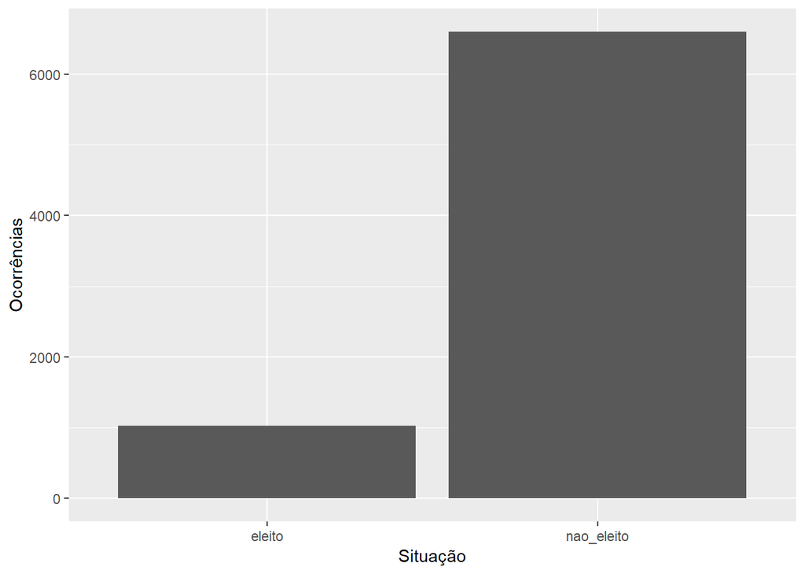

```r
dadosIniciais %>%
  ggplot(aes(situacao)) +
  geom_bar() +
  labs(x="Situação", y="Ocorrências")
```

Como é possível observar, existe um desbalanceamento entre as duas classes presentes, uma vez que ‘não_eleito’ possui muito mais ocorrências que ‘eleito’. Um desbalanceamento desta forma pode prejudicar o classificador, pois o mesmo pode obter um viés para classificar as classes para ‘nao_eleito’ devido a possuir mais ocorrências. Uma forma de tratar isto é balanceando as classes, o pacote caret fornece modelos para balanceamento na etapa de treino, como down-sampling. Outra forma interessante é adicionar ocorrências da variável ‘eleito’ de modo a obter uma melhor proporção dos dados.

### 2) Treine: um modelo de KNN, regressão logística, uma árvore de decisão e um modelo de adaboost. Tune esses modelos usando validação cruzada e controle overfitting se necessário, considerando as particularidades de cada modelo. (20 pts.)

Na etapa de treinamento, consegui melhores resultados retirando as variáveis (cargo, nome, ocupacao, partido, estado_civil, grau) do modelo (algumas também possuiam zero variância). Apenas no modelo KNN aperfeicoei os paramêtros do modelo. Nos demais, os parâmetros default geraram bons resultados.

Modelo KNN:

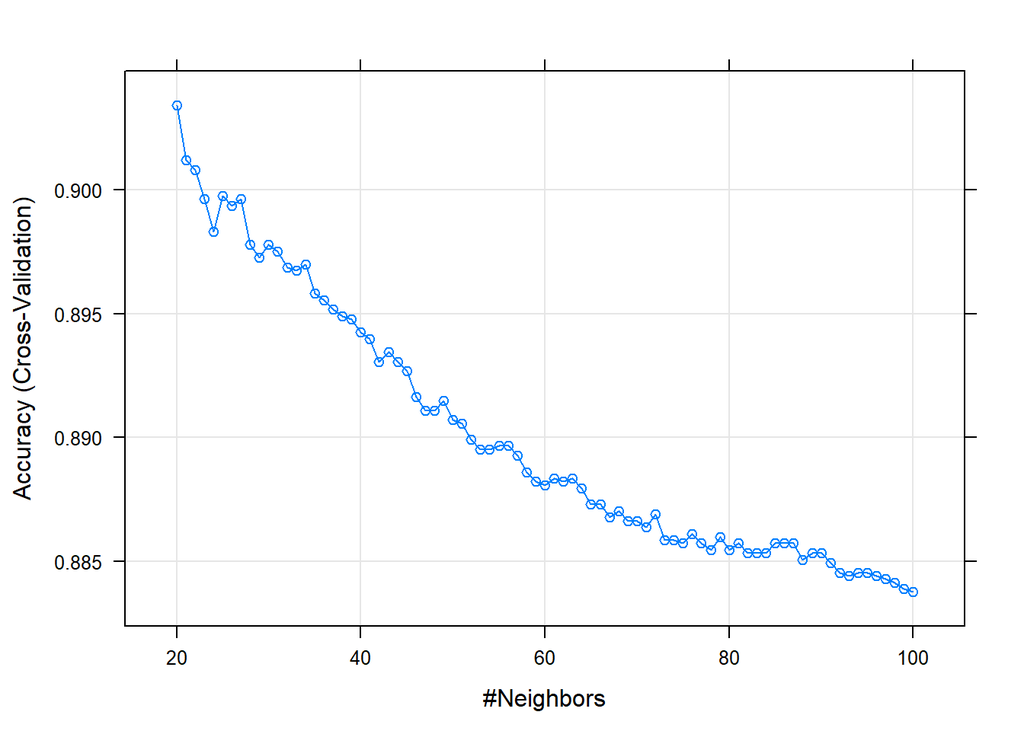

```r
knnModel <- train (situacao ~ .,
                 data = dadosIniciais %>% select(-cargo, -nome, -ocupacao, -partido, -estado_civil, -grau),
                 method = "knn",
                 preProc = c("center", "scale"),
                 trControl = cctrl1,
                 tuneGrid = expand.grid(k = seq(20, 100, length=81)))

plot(knnModel)
```

```r
knnModel
```

```
## k-Nearest Neighbors
##
## 7622 samples
##   17 predictor
##    2 classes: 'eleito', 'nao_eleito'
##
## Pre-processing: centered (42), scaled (42)
## Resampling: Cross-Validated (3 fold)
## Summary of sample sizes: 5082, 5081, 5081
## Resampling results across tuning parameters:
##
##   k    Accuracy   Kappa
##    20  0.9034378  0.4733938
##    21  0.9012071  0.4577192
##    22  0.9008138  0.4535606
```

[output cut: 81 more lines]

Modelo de Regressão Logística:

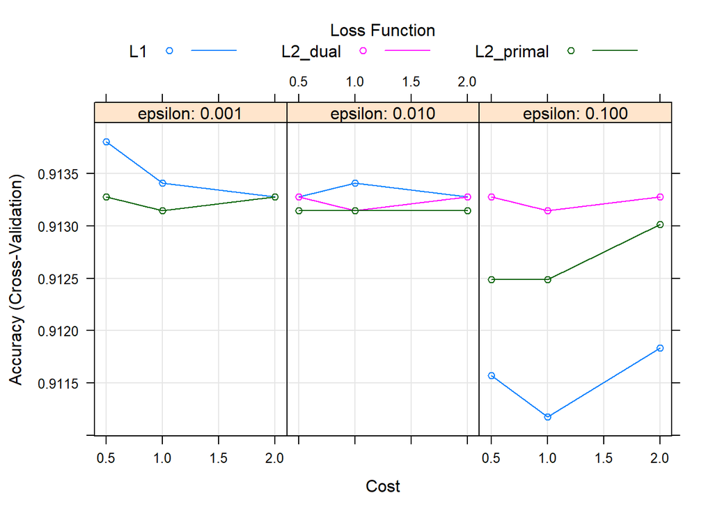

```r
logisticModel <- train (situacao ~ .,
                 data = dadosIniciais %>% select(-cargo, -nome, -ocupacao, -partido, -estado_civil, -grau),
                 method = "regLogistic",
                 preProc = c("center", "scale"),
                 trControl = cctrl1)

plot(logisticModel)
```

```r
logisticModel
```

```
## Regularized Logistic Regression
##
## 7622 samples
##   17 predictor
##    2 classes: 'eleito', 'nao_eleito'
##
## Pre-processing: centered (42), scaled (42)
## Resampling: Cross-Validated (3 fold)
## Summary of sample sizes: 5082, 5081, 5081
## Resampling results across tuning parameters:
##
##   cost  loss       epsilon  Accuracy   Kappa
##   0.5   L1         0.001    0.9138020  0.5666588
##   0.5   L1         0.010    0.9132773  0.5644246
##   0.5   L1         0.100    0.9115718  0.5551420
##   0.5   L2_dual    0.001    0.9132773  0.5652586
##   0.5   L2_dual    0.010    0.9132773  0.5652586
##   0.5   L2_dual    0.100    0.9132773  0.5652586
##   0.5   L2_primal  0.001    0.9132773  0.5652586
##   0.5   L2_primal  0.010    0.9131461  0.5643791
##   0.5   L2_primal  0.100    0.9124902  0.5604022
##   1.0   L1         0.001    0.9134085  0.5648532
##   1.0   L1         0.010    0.9134084  0.5652843
##   1.0   L1         0.100    0.9111782  0.5537716
##   1.0   L2_dual    0.001    0.9131460  0.5639329
##   1.0   L2_dual    0.010    0.9131460  0.5639329
##   1.0   L2_dual    0.100    0.9131460  0.5639329
##   1.0   L2_primal  0.001    0.9131460  0.5639329
##   1.0   L2_primal  0.010    0.9131460  0.5639329
##   1.0   L2_primal  0.100    0.9124901  0.5608113
##   2.0   L1         0.001    0.9132773  0.5643813
##   2.0   L1         0.010    0.9132772  0.5635524
##   2.0   L1         0.100    0.9118342  0.5556046
##   2.0   L2_dual    0.001    0.9132772  0.5639567
##   2.0   L2_dual    0.010    0.9132772  0.5639567
##   2.0   L2_dual    0.100    0.9132772  0.5639567
##   2.0   L2_primal  0.001    0.9132772  0.5639567
##   2.0   L2_primal  0.010    0.9131460  0.5630747
##   2.0   L2_primal  0.100    0.9130149  0.5630316
##
## Accuracy was used to select the optimal model using the largest value.
## The final values used for the model were cost = 0.5, loss = L1 and
##  epsilon = 0.001.
```

Modelo de Árvore de Decisão:

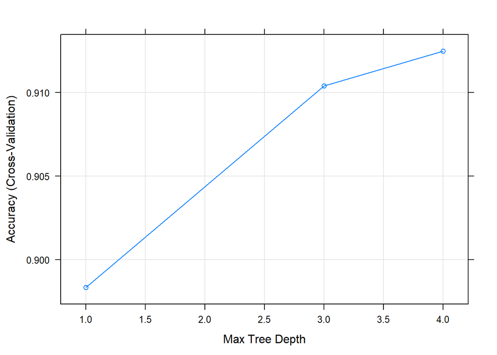

```r
dtModel <- train (situacao ~ .,
                 data = dadosIniciais %>% select(-cargo, -nome, -ocupacao, -partido, -estado_civil, -grau),
                 method = "rpart2",
                 preProc = c("center", "scale"),
                 trControl = cctrl1)

plot(dtModel)
```

```r
dtModel
```

```
## CART
##
## 7622 samples
##   17 predictor
##    2 classes: 'eleito', 'nao_eleito'
##
## Pre-processing: centered (42), scaled (42)
## Resampling: Cross-Validated (3 fold)
## Summary of sample sizes: 5081, 5081, 5082
## Resampling results across tuning parameters:
##
##   maxdepth  Accuracy   Kappa
##   1         0.8983214  0.6350696
##   3         0.9103918  0.6189058
##   4         0.9124908  0.6221339
##
## Accuracy was used to select the optimal model using the largest value.
## The final value used for the model was maxdepth = 4.
```

Modelo de Boosting:

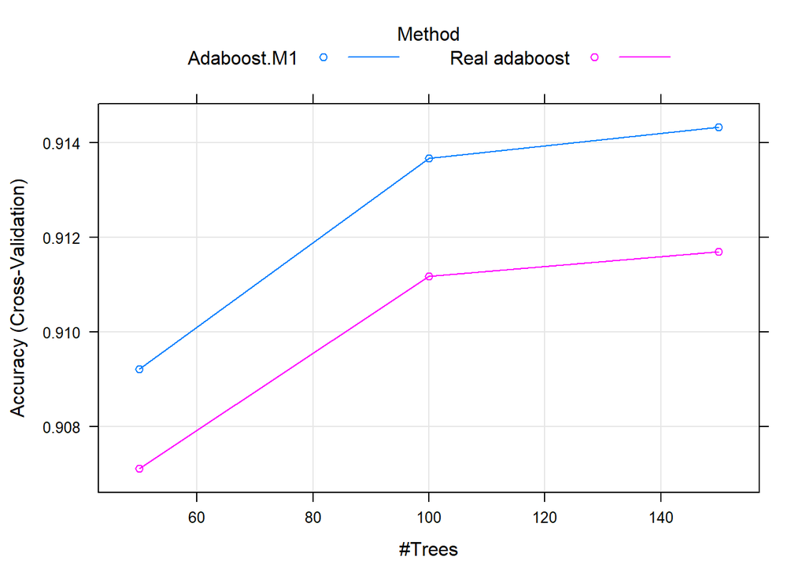

```r
adaModel <- train (situacao ~ .,
                 data = dadosIniciais %>% select(-cargo, -nome, -ocupacao, -partido, -estado_civil, -grau),
                 method = "adaboost",
                 preProc = c("center", "scale"),
                 trControl = cctrl1)

plot(adaModel)
```

```r
adaModel
```

```
## AdaBoost Classification Trees
##
## 7622 samples
##   17 predictor
##    2 classes: 'eleito', 'nao_eleito'
##
## Pre-processing: centered (42), scaled (42)
## Resampling: Cross-Validated (3 fold)
## Summary of sample sizes: 5081, 5082, 5081
## Resampling results across tuning parameters:
##
##   nIter  method         Accuracy   Kappa
##    50    Adaboost.M1    0.9092102  0.6021262
##    50    Real adaboost  0.9071112  0.5830700
##   100    Adaboost.M1    0.9136710  0.6223828
##   100    Real adaboost  0.9111783  0.6072685
##   150    Adaboost.M1    0.9143269  0.6249612
##   150    Real adaboost  0.9117031  0.6091484
##
## Accuracy was used to select the optimal model using the largest value.
## The final values used for the model were nIter = 150 and method
##  = Adaboost.M1.
```

### 5) Envie seus melhores modelos à competição do Kaggle. Faça pelo menos uma submissão. Sugestões para melhorar o modelo:

Realizei o teste em vários modelos e consegui o melhor resultado com o Multilayer Perceptron (MLP), utilizando repeated cross validation. Também obtive bom resultado utilizando eXtreme Gradient Boosting.

```r
mlpModel <- train (situacao ~ .,
                 data = dadosIniciais %>% select(-cargo, -nome, -ocupacao, -partido, -estado_civil, -grau),
                 method = "mlp",
                 preProc = c("center", "scale"),
                 trControl = ctrl,
                 tuneGrid = expand.grid(size = 5))
mlpModel
```

```
## Multi-Layer Perceptron
##
## 7622 samples
##   17 predictor
##    2 classes: 'eleito', 'nao_eleito'
##
## Pre-processing: centered (42), scaled (42)
## Resampling: Cross-Validated (3 fold, repeated 10 times)
## Summary of sample sizes: 5081, 5082, 5081, 5082, 5081, 5081, ...
## Resampling results:
##
##   Accuracy   Kappa
##   0.9167281  0.6442614
##
## Tuning parameter 'size' was held constant at a value of 5
```

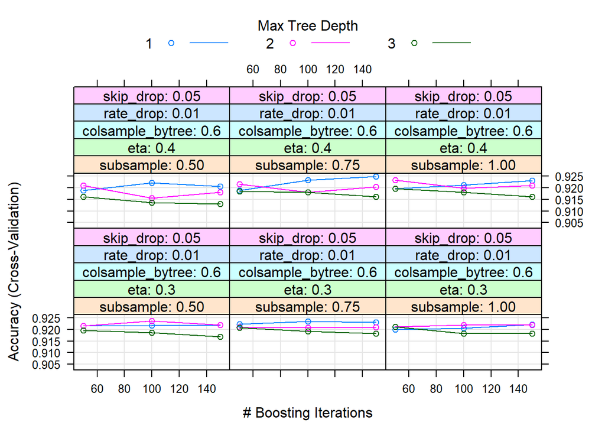

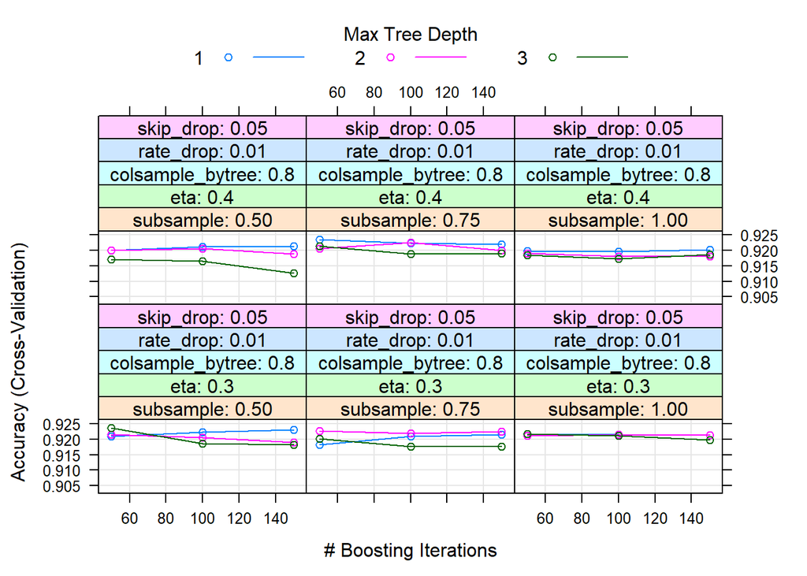

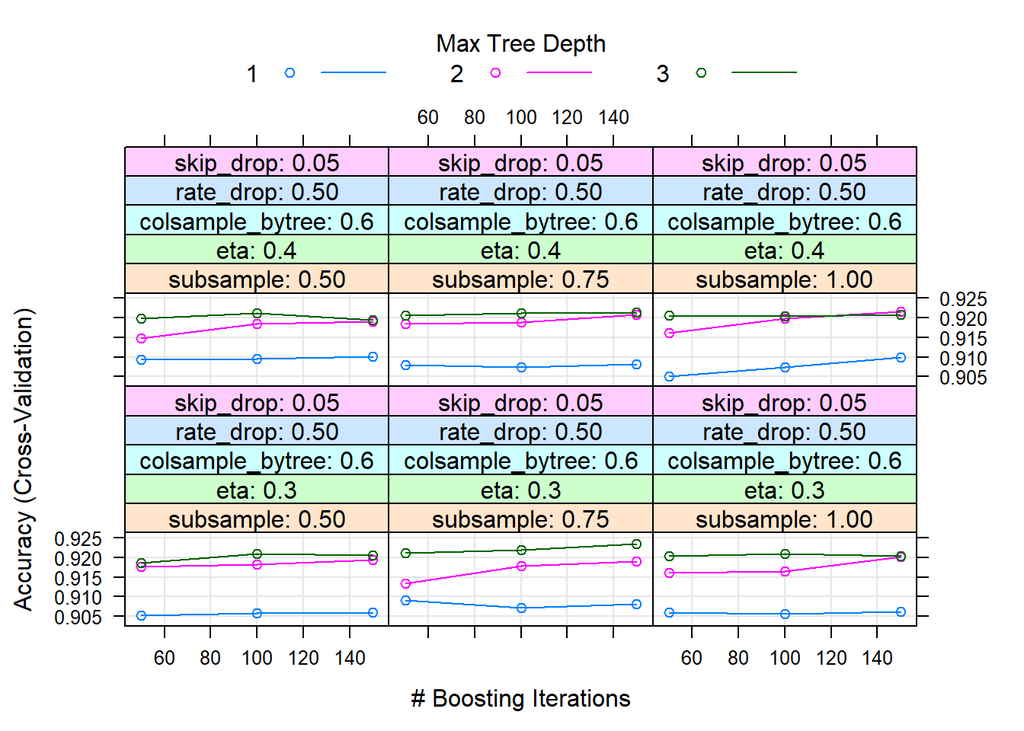

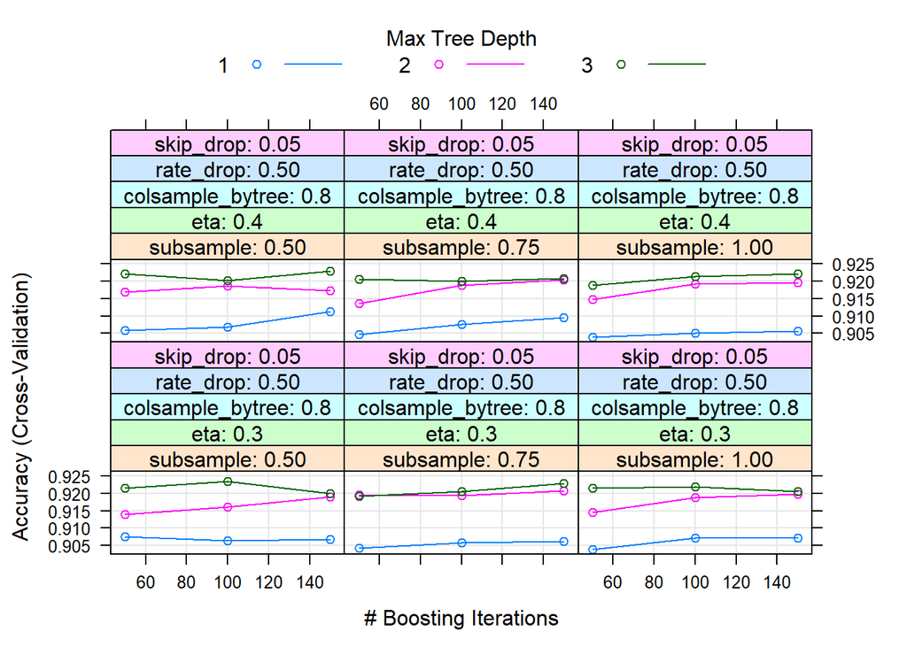

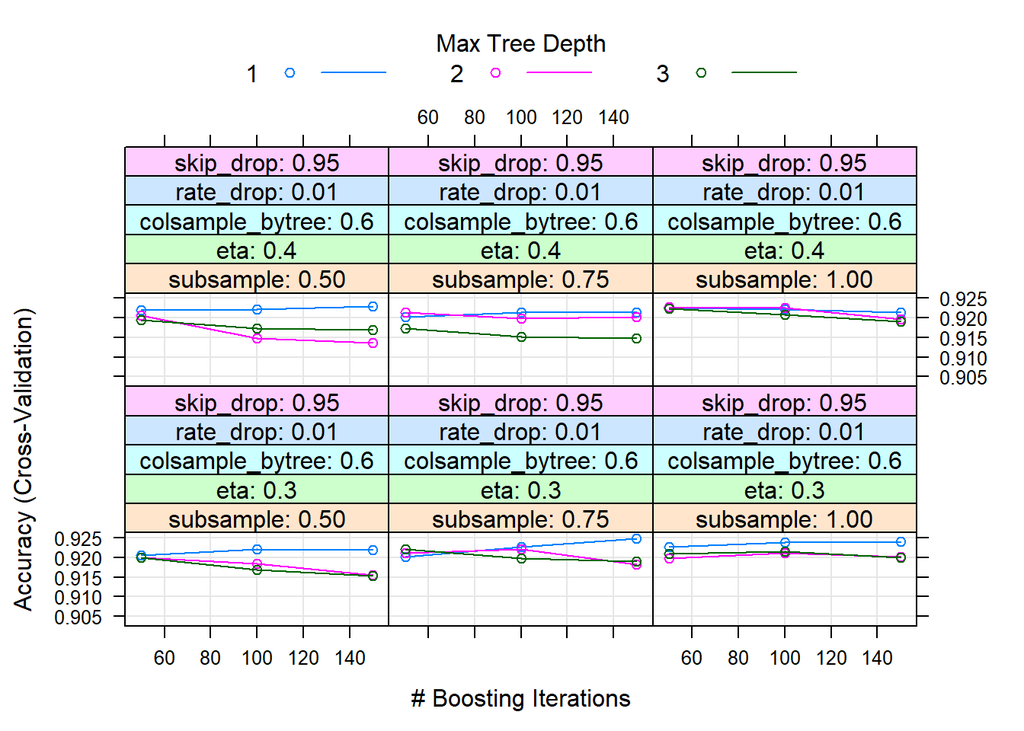

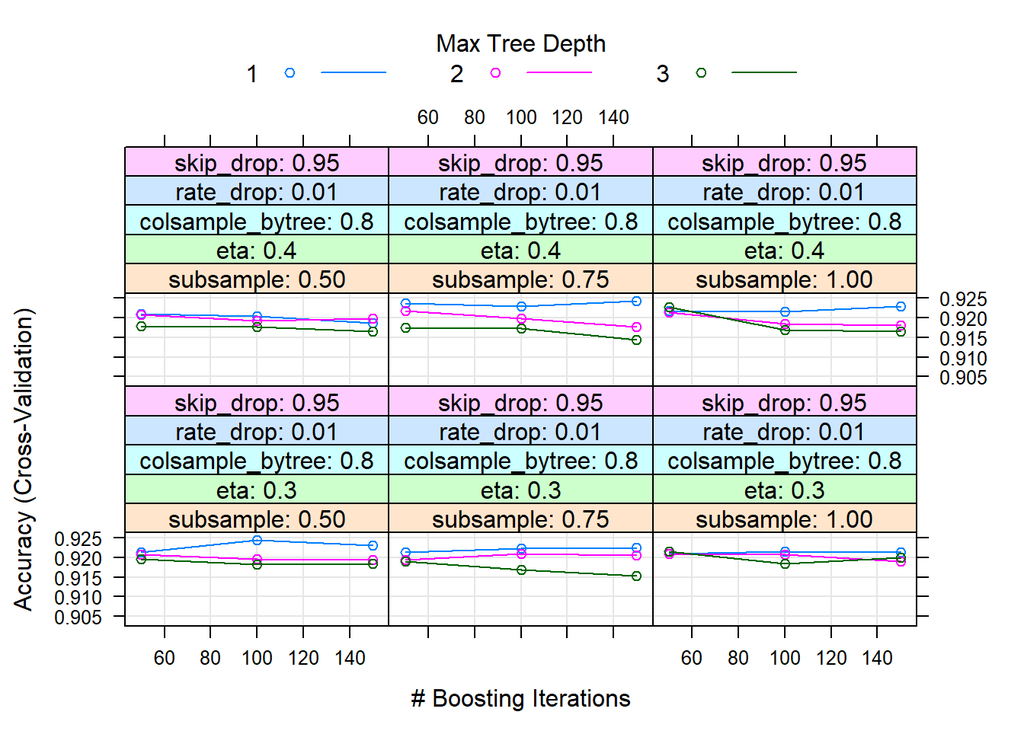

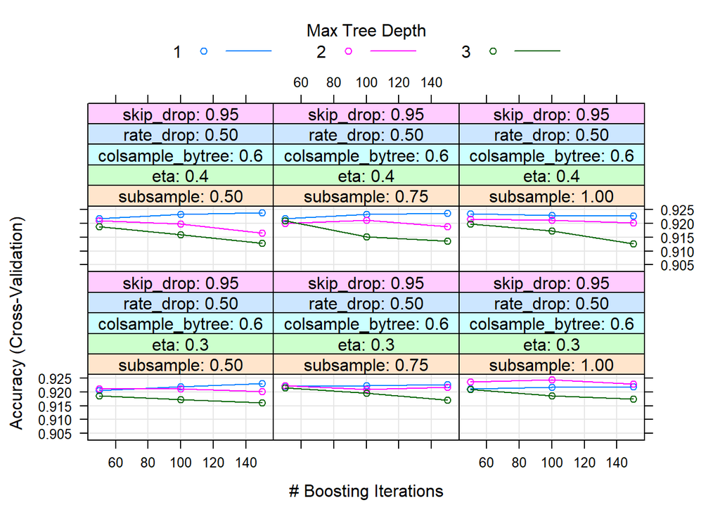

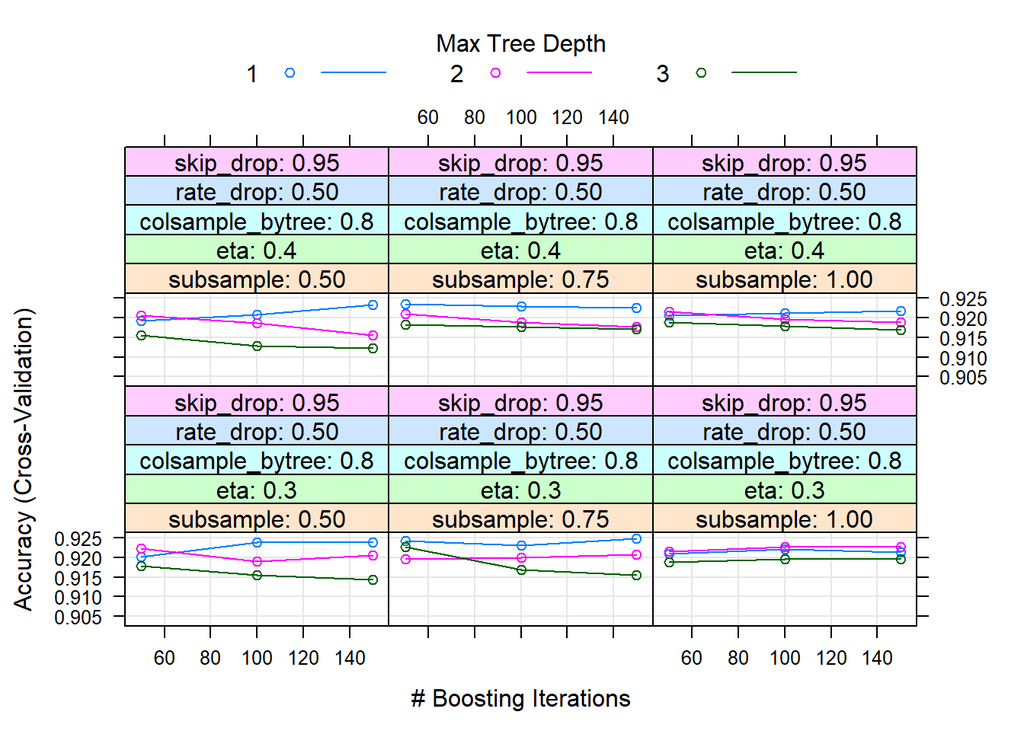

```r
xgModel <- train (situacao ~ .,
                 data = dadosIniciais %>% select(-cargo, -nome, -ocupacao, -partido, -estado_civil, -grau),
                 method = "xgbDART",
                 preProc = c("center", "scale"),
                 trControl = cctrl1)

plot(xgModel)
```

```r
predict <- predict(mlpModel, teste)
result <- data.frame(ID= teste$sequencial_candidato, Predicted= predict)
result$ID <- as.character(result$ID)
result %>% write_csv(path = "resultout.csv")
```